# Associate Rules-Car Evaluation

In this paper I will present analysis about car evaluation. Data set is from Machine Learning Depository and Has 1728 observations with 7 variables presented below. I will use associated rules algorithm to present probabilities.

```r
#Libraries
library(arules)
library(arulesViz)
library(colorspace)

#Reading data
cars<-read.csv('cars.csv',header=TRUE,sep=",")
#The factors of variables
str(cars)
```

```
## 'data.frame':    1728 obs. of  7 variables:
##  $ buying  : Factor w/ 4 levels "high","low","med",..: 4 4 4 4 4 4 4 4 4 4 ...
##  $ main    : Factor w/ 4 levels "high","low","med",..: 4 4 4 4 4 4 4 4 4 4 ...
##  $ doors   : Factor w/ 4 levels "2","3","4","5more": 1 1 1 1 1 1 1 1 1 1 ...
##  $ persons : Factor w/ 3 levels "2","4","more": 1 1 1 1 1 1 1 1 1 2 ...
##  $ lug_boot: Factor w/ 3 levels "big","med","small": 3 3 3 2 2 2 1 1 1 3 ...
##  $ safety  : Factor w/ 3 levels "high","low","med": 2 3 1 2 3 1 2 3 1 2 ...
##  $ class   : Factor w/ 4 levels "acc","good","unacc",..: 3 3 3 3 3 3 3 3 3 3 ...
```

```r
#Here is quick summary of the data.
summary(cars)
```

```
##    buying       main       doors     persons     lug_boot    safety
##  high :432   high :432   2    :432   2   :576   big  :576   high:576
##  low  :432   low  :432   3    :432   4   :576   med  :576   low :576
##  med  :432   med  :432   4    :432   more:576   small:576   med :576
##  vhigh:432   vhigh:432   5more:432
##    class
##  acc  : 384
##  good :  69
##  unacc:1210
##  vgood:  65
```

```r
inspect(rules)
```

```
##      lhs                            rhs           support   confidence
## [1]  {buying=vhigh}              => {class=unacc} 0.2083333 0.8333333
## [2]  {main=vhigh}                => {class=unacc} 0.2083333 0.8333333
## [3]  {safety=low}                => {class=unacc} 0.3333333 1.0000000
## [4]  {persons=2}                 => {class=unacc} 0.3333333 1.0000000
## [5]  {lug_boot=big,safety=low}   => {class=unacc} 0.1111111 1.0000000
## [6]  {persons=2,lug_boot=big}    => {class=unacc} 0.1111111 1.0000000
## [7]  {persons=4,safety=low}      => {class=unacc} 0.1111111 1.0000000
## [8]  {persons=more,safety=low}   => {class=unacc} 0.1111111 1.0000000
## [9]  {lug_boot=med,safety=low}   => {class=unacc} 0.1111111 1.0000000
## [10] {persons=2,lug_boot=med}    => {class=unacc} 0.1111111 1.0000000
## [11] {persons=2,safety=high}     => {class=unacc} 0.1111111 1.0000000
## [12] {persons=2,safety=med}      => {class=unacc} 0.1111111 1.0000000
## [13] {lug_boot=small,safety=low} => {class=unacc} 0.1111111 1.0000000
## [14] {persons=2,safety=low}      => {class=unacc} 0.1111111 1.0000000
```

[output cut: 17 more lines]

We see that all variables has the same amount of observations for each factor besides class of the car. So what makes car unattractive or attractive?

# Hypotesis one: Unattractive car

To test this hypotesis I will use apriori algorithm which produce itemsets and rules. Results below are sorted by confidence.

```r
rules.by.conf<-sort(rules, by="confidence", decreasing=TRUE)
inspect(head(rules.by.conf))
```

```
##     lhs                          rhs           support   confidence
## [1] {safety=low}              => {class=unacc} 0.3333333 1
## [2] {persons=2}               => {class=unacc} 0.3333333 1
## [3] {lug_boot=big,safety=low} => {class=unacc} 0.1111111 1
## [4] {persons=2,lug_boot=big}  => {class=unacc} 0.1111111 1
## [5] {persons=4,safety=low}    => {class=unacc} 0.1111111 1
## [6] {persons=more,safety=low} => {class=unacc} 0.1111111 1
##     lift     count
## [1] 1.428099 576
## [2] 1.428099 576
## [3] 1.428099 192
## [4] 1.428099 192
## [5] 1.428099 192
## [6] 1.428099 192
```

Confidence tell us the conditional probability of seeing rhs under the condition of lhs. In our case we can confront now one of our hypotesis that we see cars with low safety or which can only have two persons are considered unattractive. With which feature unattracive car mostly connects?

```r
rules.unacc<-apriori(cars, parameter=list(supp=0.001,conf = 0.08),
                     appearance=list(default="rhs",lhs="class=unacc"), control=list(verbose=F))
rules.unacc.byconf<-sort(rules.unacc, by="confidence", decreasing=TRUE)
inspect(rules.unacc.byconf[1:15])
```

```
##      lhs              rhs              support   confidence lift
## [1]  {class=unacc} => {safety=low}     0.3333333 0.4760331  1.4280992
## [2]  {class=unacc} => {persons=2}      0.3333333 0.4760331  1.4280992
## [3]  {class=unacc} => {lug_boot=small} 0.2604167 0.3719008  1.1157025
## [4]  {}            => {persons=more}   0.3333333 0.3333333  1.0000000
## [5]  {}            => {persons=4}      0.3333333 0.3333333  1.0000000
## [6]  {}            => {lug_boot=big}   0.3333333 0.3333333  1.0000000
## [7]  {}            => {lug_boot=med}   0.3333333 0.3333333  1.0000000
## [8]  {}            => {safety=high}    0.3333333 0.3333333  1.0000000
## [9]  {}            => {safety=med}     0.3333333 0.3333333  1.0000000
## [10] {}            => {safety=low}     0.3333333 0.3333333  1.0000000
## [11] {}            => {lug_boot=small} 0.3333333 0.3333333  1.0000000
## [12] {}            => {persons=2}      0.3333333 0.3333333  1.0000000
## [13] {class=unacc} => {lug_boot=med}   0.2268519 0.3239669  0.9719008
## [14] {class=unacc} => {lug_boot=big}   0.2129630 0.3041322  0.9123967
```

[output cut: 17 more lines]

The unattractive car will mostly have:

- Safety=low
- Persons=2
- Lug_boot=small, med., big
- Safety=med

We see that the our most frequent group has mostly all types of groups of lug_boot.  
Plot belows confirms that cars with low safety are mostly considered as unattractive cars.

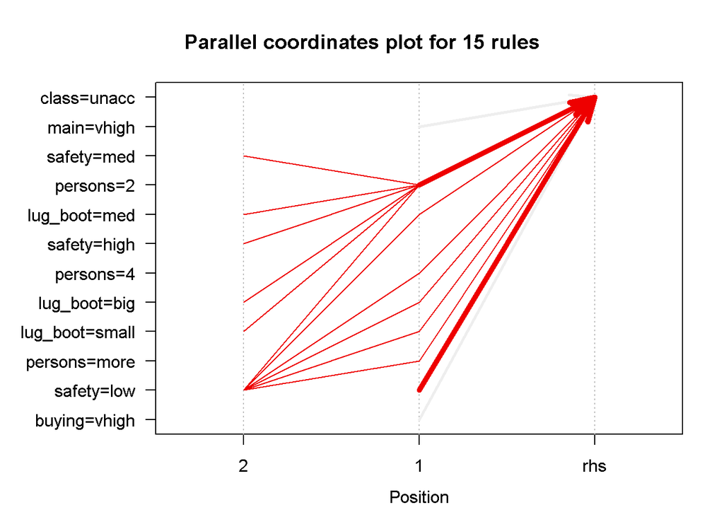

```r
plot(rules, method = "paracoord", control = list(reorder = TRUE))
```

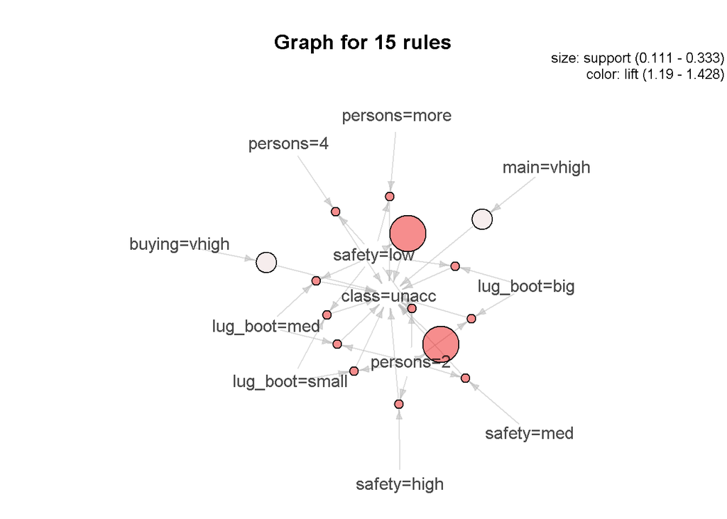

```r
#Additional plot
plot(rules,method="graph")
```

# Hypotesis two: Very good car

In another way we would consider cars with high safety, low maintenance and which can have 4 or 5 and more persons a attractive car. Is it true? The results below are sorted by confidence.

```r
rules.vgood<-apriori(cars, parameter=list(supp=0.001,conf = 0.08),
                      appearance=list(default="lhs",rhs="class=vgood"), control=list(verbose=F))
rules.vgood.byconf<-sort(rules.vgood, by="confidence", decreasing=TRUE)
inspect(rules.vgood.byconf[1:15])
```

```
##      lhs               rhs               support confidence     lift count
## [1]  {buying=med,
##       main=low,
##       persons=4,
##       lug_boot=big,
##       safety=high}  => {class=vgood} 0.002314815       1.00 26.58462     4
## [2]  {buying=med,
##       main=low,
##       persons=more,
##       lug_boot=big,
##       safety=high}  => {class=vgood} 0.002314815       1.00 26.58462     4
## [3]  {buying=med,
##       main=med,
##       persons=4,
##       lug_boot=big,
##       safety=high}  => {class=vgood} 0.002314815       1.00 26.58462     4
## [4]  {buying=med,
##       main=med,
##       persons=more,
##       lug_boot=big,
##       safety=high}  => {class=vgood} 0.002314815       1.00 26.58462     4
## [5]  {buying=low,
##       main=low,
##       persons=4,
##       lug_boot=big,
##       safety=high}  => {class=vgood} 0.002314815       1.00 26.58462     4
## [6]  {buying=low,
##       main=low,
##       persons=more,
##       lug_boot=big,
##       safety=high}  => {class=vgood} 0.002314815       1.00 26.58462     4
## [7]  {buying=low,
##       main=med,
##       persons=4,
##       lug_boot=big,
##       safety=high}  => {class=vgood} 0.002314815       1.00 26.58462     4
## [8]  {buying=low,
##       main=med,
##       persons=more,
##       lug_boot=big,
```

[output cut: 19 more lines]

```
## [13] {buying=med,
##       main=low,
##       persons=more,
##       lug_boot=med,
##       safety=high}  => {class=vgood} 0.001736111       0.75 19.93846     3
## [14] {buying=med,
##       main=med,
##       persons=more,
##       lug_boot=med,
##       safety=high}  => {class=vgood} 0.001736111       0.75 19.93846     3
## [15] {buying=low,
##       main=low,
##       persons=more,
##       lug_boot=med,
##       safety=high}  => {class=vgood} 0.001736111       0.75 19.93846     3
```

We can tell that in this data set to consider car very good it has to mostly the best features and not even one bad. In other way if we know thar car is very good with which feature it usually connects?

```r
rules.vgood<-apriori(cars, parameter=list(supp=0.001,conf = 0.08),
                      appearance=list(default="rhs",lhs="class=vgood"), control=list(verbose=F))
rules.vgood.byconf<-sort(rules.vgood, by="confidence", decreasing=TRUE)
inspect(rules.vgood.byconf[1:15])
```

```
##      lhs              rhs            support    confidence lift     count
## [1]  {class=vgood} => {safety=high}  0.03761574 1.0000000  3.000000   65
## [2]  {}            => {class=unacc}  0.70023148 0.7002315  1.000000 1210
## [3]  {class=vgood} => {lug_boot=big} 0.02314815 0.6153846  1.846154   40
## [4]  {class=vgood} => {buying=low}   0.02256944 0.6000000  2.400000   39
## [5]  {class=vgood} => {persons=more} 0.02025463 0.5384615  1.615385   35
## [6]  {class=vgood} => {persons=4}    0.01736111 0.4615385  1.384615   30
## [7]  {class=vgood} => {buying=med}   0.01504630 0.4000000  1.600000   26
## [8]  {class=vgood} => {main=low}     0.01504630 0.4000000  1.600000   26
## [9]  {class=vgood} => {main=med}     0.01504630 0.4000000  1.600000   26
## [10] {class=vgood} => {lug_boot=med} 0.01446759 0.3846154  1.153846   25
## [11] {}            => {lug_boot=big} 0.33333333 0.3333333  1.000000  576
## [12] {}            => {persons=4}    0.33333333 0.3333333  1.000000  576
## [13] {}            => {persons=more} 0.33333333 0.3333333  1.000000  576
## [14] {}            => {lug_boot=med} 0.33333333 0.3333333  1.000000  576
## [15] {}            => {safety=high}  0.33333333 0.3333333  1.000000  576
```

- safety=high
- lug_boot=big
- buying=low
- persons=4 or more

So mostly cars with these features are considered as very good.

# Conclusions

We can see that associate rules can be very helpful in defining the relations between variables. In this research we used data set of cars to show which features define unattractive and very good car.